# Predicting Soccer Player's Transfer Value

[figure not shown]

### Author - Akintunde Rockson

## Project Abstract

### Introduction

Every year, a plethora of soccer players move from team to team in search of many things such as more playing time, higher contracts, more trophies, or even new challenges. In most parts of the world, there are two transfer seasons, one in the winter (December-January) and one in the summer (June-August). During these times, teams negotiate with one another as buyers and sellers. The buyers try to come to an agreement with the sellers on an acceptable fee for the player that is going to be transferred. Nowadays, this fee is comfortably in the millions, with the cream of the crop having market values well over 100 million euros.

### Why is this important?

Being able to estimate the market value of a soccer player is definitely a useful task. In bidding wars that go on between multiple prospective buyers, it is important for the soccer clubs to know an accurate estimate of what a player is worth so as to make sure not to vastly overpay for a player that is simply not worth the money being requested. You can also find undervalued players with this method. Also, data analytics is taking the sports world by storm, with soccer being one of those sports. Stories like Moneyball put the sports world on notice and as a result of that, many people saw the benefits of meshing sports with data and while soccer may have been a bit late to the party, they are here now. This has manifested itself in many ways such as the creation of expected goals (xG), a metric which tells us the quality and quantity of chances one team or player produces in any given match. Stats such as these are used in pregame meetings in order to plan tactics effectively.

### How this project works

The tutorial aims to predict soccer players' transfer values in order to determine which players are overvalued and undervalued. The dataset we're using is a FIFA soccer video game dataset. We start by scraping data from the sofifa dataset which lists the stats for all the players in the game. These stats are gotten by the game developers who try to quantify the quality of each player on a scale from 1-99 so for example a soccer player who is good at scoring goals but poor at defending may have a 95 for shooting but a 32 for defending. Through this, we can build regression models in order to predict what a player's market value will be and compare it to the market value the FIFA video game has given to each player. With our best model, we will compare the differences between actual value (FIFA) and the predicted values (regression) in order to decide which player are over valued or under valued in today's market. Here is a link to the dataset: https://sofifa.com/?&showCol%5B%5D=pi&showCol%5B%5D=ae&showCol%5B%5D=hi&showCol%5B%5D=wi&showCol%5B%5D=pf&showCol%5B%5D=oa&showCol%5B%5D=pt&showCol%5B%5D=bo&showCol%5B%5D=bp&showCol%5B%5D=gu&showCol%5B%5D=vl&showCol%5B%5D=wg&showCol%5B%5D=rc&showCol%5B%5D=ta&showCol%5B%5D=cr&showCol%5B%5D=fi&showCol%5B%5D=he&showCol%5B%5D=sh&showCol%5B%5D=vo&showCol%5B%5D=ts&showCol%5B%5D=dr&showCol%5B%5D=cu&showCol%5B%5D=fr&showCol%5B%5D=lo&showCol%5B%5D=bl&showCol%5B%5D=to&showCol%5B%5D=ac&showCol%5B%5D=sp&showCol%5B%5D=ag&showCol%5B%5D=re&showCol%5B%5D=ba&showCol%5B%5D=tp&showCol%5B%5D=so&showCol%5B%5D=ju&showCol%5B%5D=st&showCol%5B%5D=sr&showCol%5B%5D=ln&showCol%5B%5D=te&showCol%5B%5D=ar&showCol%5B%5D=in&showCol%5B%5D=po&showCol%5B%5D=vi&showCol%5B%5D=pe&showCol%5B%5D=cm&showCol%5B%5D=td&showCol%5B%5D=ma&showCol%5B%5D=sa&showCol%5B%5D=sl&showCol%5B%5D=tg&showCol%5B%5D=gd&showCol%5B%5D=gh&showCol%5B%5D=gc&showCol%5B%5D=gp&showCol%5B%5D=gr&showCol%5B%5D=tt&showCol%5B%5D=bs&showCol%5B%5D=ir&showCol%5B%5D=pac&showCol%5B%5D=sho&showCol%5B%5D=pas&showCol%5B%5D=dri&showCol%5B%5D=def&showCol%5B%5D=phy&offset=1

```python
# Imports
import pandas as pd
import numpy as np
import matplotlib.pyplot as plt
%matplotlib inline
import seaborn as sns
from bs4 import BeautifulSoup
import requests
import re
import statsmodels.api as sm
import scipy.stats as stats
from sklearn import linear_model
from sklearn.linear_model import LinearRegression, Ridge, Lasso, LassoCV, RidgeCV
from sklearn.model_selection import train_test_split
from sklearn.model_selection import KFold
from sklearn.model_selection import cross_val_score
from sklearn.preprocessing import StandardScaler, PolynomialFeatures
```

```python
pd.set_option('display.max_columns', 75)
pd.set_option('display.max_rows', 100)
```

```python
import warnings #removing the warnings
warnings.filterwarnings('ignore')
```

## Data collection/curation + parsing

I scraped data on the most recent stats FIFA gave to soccer players from sofifa.com with the use of BeautifulSoup. The link shows players characteristics data and each page has 60 players so a loop was needed in order to get all the data I need.

```python
plist = []

i = 0
while i < 3000:
    url = "https://sofifa.com/?&showCol%5B%5D=pi&showCol%5B%5D=ae&showCol%5B%5D=hi&showCol%5B%5D=wi&showCol%5B%5D=pf&showCol%5B%5D=oa&showCol%5B%5D=pt&showCol%5B%5D=bo&showCol%5B%5D=bp&showCol%5B%5D=gu&showCol%5B%5D=vl&showCol%5B%5D=wg&showCol%5B%5D=rc&showCol%5B%5D=ta&showCol%5B%5D=cr&showCol%5B%5D=fi&showCol%5B%5D=he&showCol%5B%5D=sh&showCol%5B%5D=vo&showCol%5B%5D=ts&showCol%5B%5D=dr&showCol%5B%5D=cu&showCol%5B%5D=fr&showCol%5B%5D=lo&showCol%5B%5D=bl&showCol%5B%5D=to&showCol%5B%5D=ac&showCol%5B%5D=sp&showCol%5B%5D=ag&showCol%5B%5D=re&showCol%5B%5D=ba&showCol%5B%5D=tp&showCol%5B%5D=so&showCol%5B%5D=ju&showCol%5B%5D=st&showCol%5B%5D=sr&showCol%5B%5D=ln&showCol%5B%5D=te&showCol%5B%5D=ar&showCol%5B%5D=in&showCol%5B%5D=po&showCol%5B%5D=vi&showCol%5B%5D=pe&showCol%5B%5D=cm&showCol%5B%5D=td&showCol%5B%5D=ma&showCol%5B%5D=sa&showCol%5B%5D=sl&showCol%5B%5D=tg&showCol%5B%5D=gd&showCol%5B%5D=gh&showCol%5B%5D=gc&showCol%5B%5D=gp&showCol%5B%5D=gr&showCol%5B%5D=tt&showCol%5B%5D=bs&showCol%5B%5D=ir&showCol%5B%5D=pac&showCol%5B%5D=sho&showCol%5B%5D=pas&showCol%5B%5D=dri&showCol%5B%5D=def&showCol%5B%5D=phy&offset="+str(i)
    response = requests.get(url)
    page = response.text
    soup = BeautifulSoup(page,"lxml")
    rows = soup.find_all("tr")
    for row in rows:
        c = row.find_all('td')
        c_to_string = str(c)
        c_sub = (re.sub(re.compile('<.*?>'),'',c_to_string))
        plist.append(c_sub)
        res = pd.DataFrame(plist)
    i += 60
```

```python
res.drop_duplicates(subset=None, keep="first", inplace=True)
```

```python
res.to_pickle("PlayerListInitial")
res = pd.read_pickle("PlayerListInitial")
len(res)
```

```
2956
```

After the scraping process, I was left with a total of 2,956 players unique players from the sofifa website

```python
new_column_name_players = ['Name','Age','Overall','Potential','Team','Height','Weight','Foot','Best_Overall',
 'Position','Growth','Value','Wage','Release_Clause','Attacking','Crossing','Finishing','Heading_Accuracy',
 'Short_Passing','Volleys','Skill','Dribbling','Curve','FK_Accuracy','Long_Passing','Ball_Control','Movement',
 'Acceleration','Sprint_Speed','Agility','Reactions','Balance','Power','Shot_Power','Jumping','Stamina',
 'Strength','Long_Shots','Mentality','Aggression','Interceptions','Positioning','Vision','Penalties','Composure',
 'Defending','Marking','Standing_Tackle','Sliding_Tackle','Goalkeeping','GK_Diving','GK_Handling','GK_Kicking',
 'GK_Positioning','GK_Reflexes','Total_Stats','Base_Stats','Int_Reputation','PAC','SHO','PAS','DRI','DEF','PHY']
```

```python
res
```

|  | 0 |
| --- | --- |
| 0 | [] |
| 1 | [\n, \n Y. TielemansCM CDM, 23, 83, 86, \n\n\n... |
| 2 | [\n\n\n\n\nFIFA 21 Apr 23, 202173 ↗ 74 Heading... |
| 3 | [\n, \n T. CastagneRB RM LB, 24, 79, 82, \n\n\... |
| 4 | [\n, \n P. CutroneST, 22, 74, 79, \n\n\n\nVale... |
| ... | ... |
| 3043 | [\n, \n Sergio LópezRB, 21, 66, 76, \n\n\n\nRe... |
| 3044 | [\n, \n M. NérezLB LM, 32, 80, 80, \n Uruguay\... |
| 3045 | [\n, \n J. OlayinkaCM CAM LM, 19, 60, 75, \n\n... |
| 3046 | [\n, \n A. PelmardCB LB RB, 20, 69, 79, \n\n\n... |
| 3047 | [\n, \n I. VassilevLW RW ST, 19, 61, 79, \n\n\... |

2956 rows × 1 columns

This is the resulting data after scraping it from the sofifa website. As you can see, the data still needs to be organized in a clearer fashion in order for it to be understandable and presentable so we shall work on theat in the next step

## Data management/representation

```python
res = pd.read_pickle("PlayerListInitial")

res = res[0].str.split(',',expand=True)


res[1] = res[1].str.replace("\n ","")

for char in ["GK","RB","RCB","CB","LCB","LB","RWB","RDM","CDM","LDM","LWB","RM","RCM","CM","LCM","LM","LAM","CAM","RAM","RW","RF","CF","LF","LW","LS","ST","RS"]:
    res[1]=res[1].str.replace(char,"")
    res[1]=res[1].str.lstrip()

res[5] = res[5].str.replace("\n\n\n\n","")
res[5] = res[5].str.split("\n").str[0]
res[5] = res[5].str.strip()

res[6] = res[6].replace(r'Loan', np.nan, regex=True)
res = res.iloc[1:]

resWoLoan = res[res[6].notna()]
resWoLoan.drop(resWoLoan.columns[[0,6,66,67,68,69]],axis=1, inplace=True)
mask_loan = res[6].isnull()
resloan = res.loc[mask_loan].shift(-1, axis=1)
resloan.drop_duplicates(subset=[6], keep="first", inplace=True)
resloan.drop(resloan.columns[[5,6,66,67,68,69]],axis=1, inplace=True)
resWoLoan.columns = new_column_name_players
resloan.columns = new_column_name_players

res = pd.concat([resWoLoan,resloan]).reset_index()
del res["index"]

res.drop_duplicates(subset=None, keep="first",inplace=True)
```

```python
res = res[~res["Height"].str.contains("~")]
res = res[~res["Age"].str.contains("\n")]
res = res[res["Height"].str.contains("'")]
```

```python
res["Height"] = res["Height"].str[:-1]

def parse_height(height):
    height = height.split("'")
    feet = float(height[0])
    inch = float(height[1])
    return ((feet*30.48) + (inch*2.54))

res["Height"]=round(res["Height"].apply(lambda x:parse_height(x)),0)
```

```python
#Converting Weight to kg
res["Weight"] = round(res["Weight"].str.split("lbs").str[0].astype(float)*0.45359237,0)

#Cleaning to Value column and convert to decimal
res["Value"] = res["Value"].str.replace("€","")
res["Value"] = res["Value"].str.replace("M","")
res.loc[res["Value"].str.contains("K"),"Value"]=res["Value"].str.split("K").str[0].astype(float)/1000
res["Value"] = round(res["Value"].astype(float),2)
res = res.loc[res["Value"]>0]

#Cleaning Wage column and convert to decimal
res["Wage"] = res["Wage"].str.replace("€","")
res.loc[res["Wage"].str.contains("K"),"Wage"]=res["Wage"].str.split("K").str[0].astype(float)*1000
res["Wage"] = round(res["Wage"].astype(float)/1000000,5)

#Cleaning Release_Clause column and convert to decimal
res["Release_Clause"] = res["Release_Clause"].str.replace("€","")
res["Release_Clause"] = res["Release_Clause"].str.replace("M","")
res.loc[res["Release_Clause"].str.contains("K"),"Release_Clause"]=res["Release_Clause"].str.split("K").str[0].astype(float)/1000
res["Release_Clause"] = round(res["Release_Clause"].astype(float),2)

res.head(15)
```

|  | Name | Age | Overall | Potential | Team | Height | Weight | Foot | Best_Overall | Position | Growth | Value | Wage | Release_Clause | Attacking | Crossing | Finishing | Heading_Accuracy | Short_Passing | Volleys | Skill | Dribbling | Curve | FK_Accuracy | Long_Passing | Ball_Control | Movement | Acceleration | Sprint_Speed | … |
| --- | --- | --- | --- | --- | --- | --- | --- | --- | --- | --- | --- | --- | --- | --- | --- | --- | --- | --- | --- | --- | --- | --- | --- | --- | --- | --- | --- | --- | --- | --- |
| 0 | Y. Tielemans | 23 | 83 | 86 | Leicester City | 175.0 | 72.0 | Right | 85 | CM | 3 | 49.5 | 0.095 | 97.8 | 384 | 79 | 74 | 65 | 88 | 78 | 408 | 79 | 81 | 78 | 85 | 85 | 352 | 65 | 60 | … |
| 2 | T. Castagne | 24 | 79 | 82 | Leicester City | 180.0 | 80.0 | Right | 80 | RWB | 3 | 22.0 | 0.065 | 43.5 | 322 | 79 | 59 | 69 | 75 | 40 | 316 | 77 | 58 | 33 | 70 | 78 | 373 | 79 | 79 | … |
| 3 | C. Strandberg | 24 | 71 | 76 | Abha Club | 188.0 | 90.0 | Left | 73 | ST | 5 | 2.9 | 0.009 | 5.0 | 312 | 50 | 74 | 62 | 59 | 67 | 248 | 63 | 42 | 31 | 46 | 66 | 317 | 73 | 86 | … |
| 4 | J. Vardy | 33 | 87 | 87 | Leicester City | 178.0 | 74.0 | Right | 87 | ST | 0 | 51.0 | 0.170 | 96.9 | 394 | 69 | 92 | 79 | 70 | 84 | 344 | 78 | 68 | 60 | 56 | 82 | 416 | 87 | 86 | … |
| 5 | H. Barnes | 22 | 81 | 85 | Leicester City | 180.0 | 66.0 | Right | 82 | CAM | 4 | 37.5 | 0.090 | 74.1 | 345 | 78 | 78 | 46 | 77 | 66 | 376 | 82 | 76 | 69 | 68 | 81 | 410 | 85 | 83 | … |
| 6 | Nuno Mendes | 18 | 77 | 87 | Sporting CP | 175.0 | 70.0 | Left | 77 | LWB | 10 | 21.0 | 0.004 | 46.2 | 311 | 74 | 45 | 67 | 71 | 54 | 340 | 72 | 66 | 59 | 68 | 75 | 402 | 82 | 86 | … |
| 7 | S. Botman | 20 | 77 | 84 | LOSC Lille | 193.0 | 81.0 | Left | 79 | CB | 7 | 19.5 | 0.023 | 41.0 | 238 | 40 | 24 | 78 | 69 | 27 | 250 | 49 | 45 | 28 | 64 | 64 | 298 | 60 | 65 | … |
| 9 | L. Thomas | 19 | 68 | 82 | Leicester City | 178.0 | 68.0 | Left | 68 | LB | 14 | 2.7 | 0.013 | 6.8 | 264 | 67 | 38 | 57 | 61 | 41 | 277 | 67 | 51 | 42 | 51 | 66 | 349 | 79 | 75 | … |
| 11 | K. Schmeichel | 33 | 85 | 85 | Leicester City | 188.0 | 89.0 | Right | 85 | GK | 0 | 17.5 | 0.100 | 33.3 | 105 | 18 | 12 | 16 | 44 | 15 | 126 | 12 | 13 | 15 | 46 | 40 | 286 | 45 | 51 | … |
| 14 | C. Söyüncü | 24 | 80 | 85 | Leicester City | 185.0 | 82.0 | Right | 82 | CB | 5 | 29.0 | 0.069 | 57.3 | 284 | 46 | 39 | 75 | 76 | 48 | 278 | 65 | 39 | 39 | 64 | 71 | 344 | 69 | 77 | … |
| 15 | Raphinha | 23 | 82 | 87 | Leeds United | 175.0 | 68.0 | Left | 83 | LM | 5 | 46.0 | 0.110 | 90.9 | 345 | 78 | 74 | 45 | 76 | 72 | 391 | 84 | 81 | 75 | 70 | 81 | 431 | 91 | 91 | … |
| 16 | M. Lacroix | 20 | 76 | 84 | VfL Wolfsburg | 190.0 | 88.0 | Right | 78 | CB | 8 | 15.5 | 0.026 | 29.5 | 236 | 35 | 29 | 74 | 70 | 28 | 237 | 56 | 37 | 26 | 57 | 61 | 335 | 68 | 84 | … |
| 18 | K. Iheanacho | 23 | 76 | 81 | Leicester City | 185.0 | 82.0 | Left | 78 | CAM | 5 | 11.5 | 0.063 | 22.7 | 358 | 59 | 78 | 67 | 77 | 77 | 364 | 78 | 74 | 64 | 69 | 79 | 372 | 77 | 75 | … |
| 19 | J. Maddison | 23 | 82 | 86 | Leicester City | 175.0 | 73.0 | Right | 84 | CAM | 4 | 43.5 | 0.089 | 85.9 | 345 | 81 | 75 | 35 | 84 | 70 | 419 | 83 | 85 | 84 | 82 | 85 | 396 | 77 | 74 | … |
| 20 | E. Tapsoba | 21 | 81 | 88 | Bayer 04 Leverkusen | 193.0 | 78.0 | Right | 83 | CB | 7 | 48.5 | 0.048 | 92.2 | 288 | 39 | 54 | 81 | 81 | 33 | 283 | 63 | 46 | 32 | 74 | 68 | 358 | 71 | 76 | … |

To improve the dataframe, I did multiple things such as splitting columns, removing unnecessary characters (\n), body conversions (height to cm, weight to kg), price conversions, numeric conversions and removing NA columns amongst some others

```python
#Deleting some rows that composure columns is blank
res = res.loc[res["Composure"]!=" "]
res = res[res["Base_Stats"]!=' ']

#Cleaning to IR column
res["Int_Reputation"]=res["Int_Reputation"].str[:-1]
```

```python
#Convertsion to ints

converted_cols=['Age','Overall', 'Potential', 'Best_Overall','Growth','Attacking','Crossing','Finishing','Heading_Accuracy',
 'Short_Passing','Volleys','Skill','Dribbling','Curve','FK_Accuracy','Long_Passing','Ball_Control','Movement',
 'Acceleration','Sprint_Speed','Agility','Reactions','Balance','Power','Shot_Power','Jumping','Stamina',
 'Strength','Long_Shots','Mentality','Aggression','Interceptions','Positioning','Vision','Penalties','Composure',
 'Defending','Marking','Standing_Tackle','Sliding_Tackle','Goalkeeping','GK_Diving','GK_Handling','GK_Kicking',
 'GK_Positioning','GK_Reflexes','Total_Stats','Base_Stats','Int_Reputation','PAC','SHO','PAS','DRI','DEF','PHY']

for i in converted_cols:
    res[i] = res[i].astype("int")
```

```python
res.info()
```

```
<class 'pandas.core.frame.DataFrame'>
Int64Index: 2524 entries, 0 to 2954
Data columns (total 64 columns):
 #   Column            Non-Null Count  Dtype
---  ------            --------------  -----
 0   Name              2524 non-null   object
 1   Age               2524 non-null   int64
 2   Overall           2524 non-null   int64
 3   Potential         2524 non-null   int64
 4   Team              2524 non-null   object
 5   Height            2524 non-null   float64
 6   Weight            2524 non-null   float64
 7   Foot              2524 non-null   object
 8   Best_Overall      2524 non-null   int64
 9   Position          2524 non-null   object
```

[output cut: 56 more lines]

```python
#Saving Final Player List as Pickle
res.to_pickle("PlayerListFinal")
#Reading Final Player List
plist= pd.read_pickle("PlayerListFinal")
```

## Exploratory data analysis

Noe that the data is well organized, the logical next step is to take a peek into the dataframe and get an understanding of what is going on there. I decided to look into the players and clubs with the highest total transfer values as well as the mean value per position just to see if it was similar to what I expected as an avid soccer follower

```python
#Top 5 Rating Player
plist.nlargest(5,columns="Value")[["Name","Age","Team","Value"]]
```

|  | Name | Age | Team | Value |
| --- | --- | --- | --- | --- |
| 57 | K. Mbappé | 21 | Paris Saint-Germain | 185.5 |
| 141 | Neymar Jr | 28 | Paris Saint-Germain | 132.0 |
| 54 | R. Lewandowski | 31 | FC Bayern München | 124.5 |
| 115 | Bruno Fernandes | 25 | Manchester United | 121.0 |
| 195 | M. Salah | 28 | Liverpool | 120.5 |

```python
#Top 5 Mean Value based on Position
pd.DataFrame(plist.groupby("Position").Value.mean().sort_values(ascending=False)).head()
```

| Position | Value |
| --- | --- |
| CF | 19.945833 |
| LW | 19.658696 |
| RW | 19.226471 |
| CM | 14.991071 |
| GK | 14.448488 |

```python
#Top 5 Club (Mean Value)
pd.DataFrame(plist.groupby("Team").Value.mean().sort_values(ascending=False).head())
```

| Team | Value |
| --- | --- |
| Paris Saint-Germain | 41.768182 |
| FC Bayern München | 41.524000 |
| Liverpool | 35.563214 |
| Manchester City | 33.672000 |
| Atlético Madrid | 32.362500 |

```python
#Top 5 Club (Total Value)
pd.DataFrame(plist.groupby("Team").Value.sum().sort_values(ascending=False).head())
```

| Team | Value |
| --- | --- |
| FC Bayern München | 1038.10 |
| Liverpool | 995.77 |
| Paris Saint-Germain | 918.90 |
| Manchester United | 797.60 |
| Juventus | 741.20 |

[figure not shown]

```python
plt.figure(figsize=(10,10))
loc=plist.Position.value_counts()
loc.plot(kind='pie' ,autopct='%.1f',fontsize=10,subplots=True)
plt.title("Soccer Player's Positions Distribution")
plt.ylabel("")
plt.show()
```

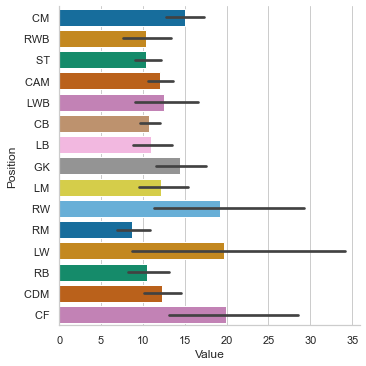

```python
plt.figure(figsize=(10,10),dpi=200)
graph = sns.catplot(y="Position", x="Value", kind="bar",  data=plist, palette="colorblind")
plt.show()
```

In general, the data exploration offered no surprises. You would expect the like of Mbappe and Neymar to have the highest market values due to their young ages and the quality they possess which has made them such household names. All the clubs that had the highest transfer values possess some of the best players so there are also no shock there. Strikers (CFs) also obviously possess higher transfer values in the market due to the importance and general flashiness associated with their job of scoring goals

## Modelling

For my first regression model, I split my data frame into two parts: Xb, yb. This is just the starter model. Xb was made to include all numeric columns while yb is the target column so it only contains the value

```python
# Slice data into faeture and target
Xb= plist.drop(columns=["Value","Name","Team","Foot","Position"])
yb= plist.loc[:,"Value"]

# fit model with target as player market value
pmodelb = sm.OLS(yb, Xb, data=plist)
ressb = pmodelb.fit()
print(ressb.summary())
```

```
                                 OLS Regression Results
=======================================================================================
Dep. Variable:                  Value   R-squared (uncentered):                   0.972
Model:                            OLS   Adj. R-squared (uncentered):              0.972
Method:                 Least Squares   F-statistic:                              1757.
Date:                Sun, 16 May 2021   Prob (F-statistic):                        0.00
Time:                        16:51:33   Log-Likelihood:                         -6602.5
No. Observations:                2524   AIC:                                  1.330e+04
Df Residuals:                    2475   BIC:                                  1.359e+04
Df Model:                          49
Covariance Type:            nonrobust
====================================================================================
                       coef    std err          t      P>|t|      [0.025      0.975]
------------------------------------------------------------------------------------
Age                 -0.5256      0.037    -14.057      0.000      -0.599      -0.452
Overall              0.3529      0.059      5.995      0.000       0.237       0.468
Potential            0.1187      0.032      3.680      0.000       0.055       0.182
Height              -0.0621      0.012     -5.099      0.000      -0.086      -0.038
Weight               0.0210      0.017      1.259      0.208      -0.012       0.054
Best_Overall        -0.1587      0.089     -1.792      0.073      -0.332       0.015
Growth              -0.2342      0.033     -7.093      0.000      -0.299      -0.169
Wage                38.8543      2.862     13.576      0.000      33.242      44.467
Release_Clause       0.4125      0.004    106.011      0.000       0.405       0.420
Attacking            0.0046      0.008      0.567      0.571      -0.011       0.020
Crossing            -0.0230      0.012     -1.968      0.049      -0.046   -8.65e-05
Finishing           -0.0131      0.026     -0.504      0.614      -0.064       0.038
Heading_Accuracy     0.0030      0.014      0.211      0.833      -0.025       0.031
Short_Passing        0.0175      0.020      0.858      0.391      -0.023       0.058
Volleys              0.0200      0.011      1.796      0.073      -0.002       0.042
Skill               -0.0104      0.009     -1.140      0.254      -0.028       0.007
Dribbling            0.0134      0.028      0.484      0.628      -0.041       0.068
Curve                0.0083      0.012      0.669      0.503      -0.016       0.033
FK_Accuracy          0.0290      0.011      2.614      0.009       0.007       0.051
Long_Passing        -0.0260      0.015     -1.695      0.090      -0.056       0.004
Ball_Control        -0.0350      0.022     -1.570      0.117      -0.079       0.009
Movement            -0.0006      0.010     -0.059      0.953      -0.021       0.020
Acceleration        -0.0004      0.027     -0.014      0.989      -0.054       0.053
Sprint_Speed        -0.0015      0.031     -0.048      0.962      -0.063       0.060
Agility              0.0029      0.018      0.154      0.877      -0.033       0.039
Reactions            0.0002      0.022      0.010      0.992      -0.042       0.042
```

[output cut: 30 more lines]

```
DRI                  0.0244      0.062      0.393      0.695      -0.097       0.146
DEF                  0.0280      0.058      0.484      0.628      -0.085       0.141
PHY                 -0.0886      0.043     -2.043      0.041      -0.174      -0.004
==============================================================================
Omnibus:                     1925.314   Durbin-Watson:                   1.357
Prob(Omnibus):                  0.000   Jarque-Bera (JB):            68163.823
Skew:                           3.259   Prob(JB):                         0.00
Kurtosis:                      27.610   Cond. No.                     1.02e+16
==============================================================================

Notes:
[1] R² is computed without centering (uncentered) since the model does not contain a constant.
[2] Standard Errors assume that the covariance matrix of the errors is correctly specified.
[3] The smallest eigenvalue is 1.01e-22. This might indicate that there are
strong multicollinearity problems or that the design matrix is singular.
```

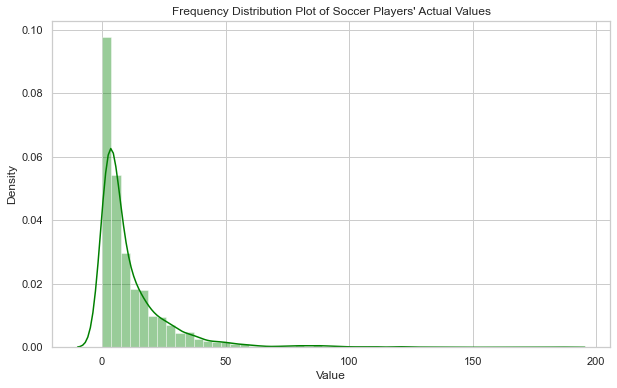

```python
sns.set(style="whitegrid")
plt.figure(figsize=(10,6))
sns.distplot(plist.Value, color='green').set_title("Frequency Distribution Plot of Soccer Players' Actual Values")
plt.show()
```

Next, we decided to look into the frequency distribution of our transfer values and we can see that there is a strong right skew which isn't good. In order to make the data more usable I decided to try a logarithmic transformation

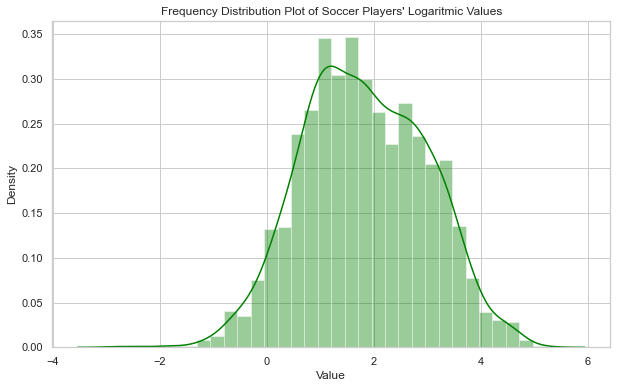

```python
sns.set(style="whitegrid")
plt.figure(figsize=(10,6))
sns.distplot(np.log(plist.Value), color='green').set_title("Frequency Distribution Plot of Soccer Players' Logaritmic Values")
```

This clearly produced much better results as the data looks much more like a normal distibution with the logarithmic transformation of the transfer values

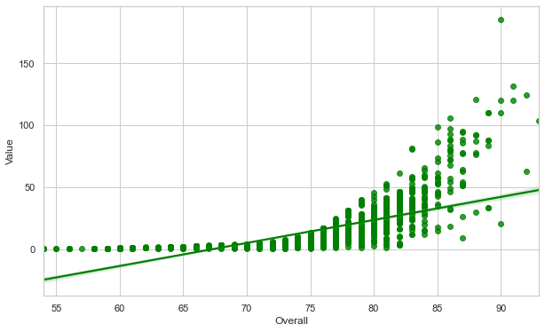

```python
plt.figure(figsize=(10,6))
sns.regplot(x="Overall",y="Value",data=plist, color='green')
```

```python
#Changing columns order
plist = plist[['Name','Value','Age','Overall','Potential','Team','Height','Weight','Foot','Best_Overall',
                           'Position','Growth','Wage','Release_Clause','Attacking','Crossing','Finishing',
                           'Heading_Accuracy','Short_Passing','Volleys','Skill','Dribbling','Curve','FK_Accuracy',
                           'Long_Passing','Ball_Control','Movement','Acceleration','Sprint_Speed','Agility',
                           'Reactions','Balance','Power','Shot_Power','Jumping','Stamina','Strength','Long_Shots',
                           'Mentality','Aggression','Interceptions','Positioning','Vision','Penalties','Composure',
                           'Defending','Marking','Standing_Tackle','Sliding_Tackle','Goalkeeping','GK_Diving',
                           'GK_Handling','GK_Kicking','GK_Positioning','GK_Reflexes','Total_Stats','Base_Stats',
                           'Int_Reputation','PAC','SHO','PAS','DRI','DEF','PHY']]
```

```python
plist['Value_log']= np.log(plist['Value'])
```

The next step in order to improve our regression model is to reduce the number of features drastically. Ideally, I would want only a few strongly correlated values to predict the transfer values instead of the 59 I have right now. In order to help with this decision making process, I will look at the correlation matrix

```python
#View the correlations
plist.corr()
```

|  | Value | Age | Overall | Potential | Height | Weight | Best_Overall | Growth | Wage | Release_Clause | Attacking | Crossing | Finishing | Heading_Accuracy | Short_Passing | Volleys | Skill | Dribbling | Curve | FK_Accuracy | Long_Passing | Ball_Control | Movement | Acceleration | Sprint_Speed | Agility | Reactions | Balance | Power | … |
| --- | --- | --- | --- | --- | --- | --- | --- | --- | --- | --- | --- | --- | --- | --- | --- | --- | --- | --- | --- | --- | --- | --- | --- | --- | --- | --- | --- | --- | --- | --- |
| Value | 1.000000 | 0.210481 | 0.725581 | 0.626865 | 0.024613 | 0.077646 | 0.731595 | -0.327396 | 0.754583 | 0.969705 | 0.253590 | 0.218337 | 0.192762 | 0.125008 | 0.318269 | 0.217642 | 0.264042 | 0.198828 | 0.237419 | 0.210985 | 0.310709 | 0.247544 | 0.254543 | 0.129131 | 0.139472 | 0.161518 | 0.653289 | 0.099086 | 0.325437 | … |
| Age | 0.210481 | 1.000000 | 0.620847 | -0.247525 | 0.098125 | 0.277630 | 0.559269 | -0.859578 | 0.406714 | 0.190972 | 0.202193 | 0.140915 | 0.117475 | 0.174326 | 0.190336 | 0.217134 | 0.170090 | 0.029036 | 0.177881 | 0.214856 | 0.243824 | 0.101923 | -0.058067 | -0.219986 | -0.217130 | -0.080838 | 0.591767 | -0.076005 | 0.309643 | … |
| Overall | 0.725581 | 0.620847 | 1.000000 | 0.455638 | 0.070642 | 0.191853 | 0.986297 | -0.753031 | 0.681417 | 0.685301 | 0.323586 | 0.278951 | 0.205386 | 0.214817 | 0.409267 | 0.267121 | 0.326952 | 0.214477 | 0.292587 | 0.267353 | 0.430434 | 0.294038 | 0.223486 | 0.036918 | 0.052610 | 0.119280 | 0.904855 | 0.045157 | 0.471504 | … |
| Potential | 0.626865 | -0.247525 | 0.455638 | 1.000000 | 0.006832 | -0.054238 | 0.492497 | 0.242607 | 0.392955 | 0.612946 | 0.061865 | 0.065624 | 0.032456 | -0.004356 | 0.182346 | 0.019136 | 0.109148 | 0.104204 | 0.067544 | 0.036211 | 0.176864 | 0.133828 | 0.196627 | 0.145005 | 0.152801 | 0.125092 | 0.378314 | 0.067573 | 0.091962 | … |
| Height | 0.024613 | 0.098125 | 0.070642 | 0.006832 | 1.000000 | 0.759864 | 0.070778 | -0.071938 | 0.043614 | 0.020163 | -0.347934 | -0.513782 | -0.374689 | 0.150458 | -0.321945 | -0.350461 | -0.469934 | -0.492626 | -0.478002 | -0.428203 | -0.268648 | -0.412704 | -0.670487 | -0.583496 | -0.412643 | -0.695852 | 0.061284 | -0.815980 | -0.105331 | … |
| Weight | 0.077646 | 0.277630 | 0.191853 | -0.054238 | 0.759864 | 1.000000 | 0.181680 | -0.249177 | 0.117544 | 0.067091 | -0.249182 | -0.419205 | -0.275222 | 0.168110 | -0.249467 | -0.237700 | -0.369135 | -0.408905 | -0.374277 | -0.314915 | -0.204317 | -0.333581 | -0.555175 | -0.518369 | -0.361898 | -0.609249 | 0.169844 | -0.663803 | 0.040877 | … |
| Best_Overall | 0.731595 | 0.559269 | 0.986297 | 0.492497 | 0.070778 | 0.181680 | 1.000000 | -0.710852 | 0.670738 | 0.692079 | 0.353985 | 0.283119 | 0.234188 | 0.247470 | 0.450498 | 0.289882 | 0.356503 | 0.248784 | 0.307164 | 0.283502 | 0.464066 | 0.333451 | 0.249445 | 0.063778 | 0.084690 | 0.140196 | 0.904647 | 0.061913 | 0.501736 | … |
| Growth | -0.327396 | -0.859578 | -0.753031 | 0.242607 | -0.071938 | -0.249177 | -0.710852 | 1.000000 | -0.452164 | -0.293785 | -0.306924 | -0.255501 | -0.199844 | -0.237333 | -0.311244 | -0.276970 | -0.275641 | -0.156718 | -0.268942 | -0.264602 | -0.338365 | -0.221528 | -0.098220 | 0.066950 | 0.055611 | -0.037530 | -0.706495 | 0.000734 | -0.445881 | … |
| Wage | 0.754583 | 0.406714 | 0.681417 | 0.392955 | 0.043614 | 0.117544 | 0.670738 | -0.452164 | 1.000000 | 0.716450 | 0.271214 | 0.228866 | 0.178919 | 0.186331 | 0.323731 | 0.228481 | 0.274460 | 0.186841 | 0.245633 | 0.238124 | 0.328231 | 0.253123 | 0.181301 | 0.048335 | 0.059333 | 0.102522 | 0.623644 | 0.065351 | 0.337297 | … |
| Release_Clause | 0.969705 | 0.190972 | 0.685301 | 0.612946 | 0.020163 | 0.067091 | 0.692079 | -0.293785 | 0.716450 | 1.000000 | 0.229648 | 0.201752 | 0.174028 | 0.109078 | 0.295091 | 0.193022 | 0.242177 | 0.177889 | 0.217510 | 0.191113 | 0.295552 | 0.225532 | 0.236167 | 0.117615 | 0.127199 | 0.147514 | 0.619272 | 0.090324 | 0.297192 | … |
| Attacking | 0.253590 | 0.202193 | 0.323586 | 0.061865 | -0.347934 | -0.249182 | 0.353985 | -0.306924 | 0.271214 | 0.229648 | 1.000000 | 0.828416 | 0.879564 | 0.637819 | 0.854711 | 0.895145 | 0.913155 | 0.908610 | 0.850933 | 0.747739 | 0.665336 | 0.927619 | 0.664415 | 0.549968 | 0.542358 | 0.589625 | 0.369136 | 0.542517 | 0.818309 | … |
| Crossing | 0.218337 | 0.140915 | 0.278951 | 0.065624 | -0.513782 | -0.419205 | 0.283119 | -0.255501 | 0.228866 | 0.201752 | 0.828416 | 1.000000 | 0.643826 | 0.336298 | 0.774335 | 0.663579 | 0.877402 | 0.848124 | 0.851456 | 0.720464 | 0.694035 | 0.822619 | 0.714206 | 0.606128 | 0.548814 | 0.663811 | 0.272606 | 0.648301 | 0.594941 | … |
| Finishing | 0.192762 | 0.117475 | 0.205386 | 0.032456 | -0.374689 | -0.275222 | 0.234188 | -0.199844 | 0.178919 | 0.174028 | 0.879564 | 0.643826 | 1.000000 | 0.364681 | 0.609237 | 0.905631 | 0.774625 | 0.806506 | 0.768491 | 0.693043 | 0.402682 | 0.765856 | 0.635205 | 0.544850 | 0.506288 | 0.608155 | 0.250943 | 0.531548 | 0.696295 | … |
| Heading_Accuracy | 0.125008 | 0.174326 | 0.214817 | -0.004356 | 0.150458 | 0.168110 | 0.247470 | -0.237333 | 0.186331 | 0.109078 | 0.637819 | 0.336298 | 0.364681 | 1.000000 | 0.579035 | 0.391352 | 0.428806 | 0.460138 | 0.310187 | 0.226710 | 0.412563 | 0.571938 | 0.179163 | 0.156859 | 0.286754 | 0.032641 | 0.285882 | 0.012892 | 0.657214 | … |
| Short_Passing | 0.318269 | 0.190336 | 0.409267 | 0.182346 | -0.321945 | -0.249467 | 0.450498 | -0.311244 | 0.323731 | 0.295091 | 0.854711 | 0.774335 | 0.609237 | 0.579035 | 1.000000 | 0.641516 | 0.889960 | 0.831062 | 0.746253 | 0.684555 | 0.875373 | 0.912718 | 0.582574 | 0.440959 | 0.428046 | 0.506699 | 0.434728 | 0.502096 | 0.707323 | … |
| Volleys | 0.217642 | 0.217134 | 0.267121 | 0.019136 | -0.350461 | -0.237700 | 0.289882 | -0.276970 | 0.228481 | 0.193022 | 0.895145 | 0.663579 | 0.905631 | 0.391352 | 0.641516 | 1.000000 | 0.800852 | 0.788075 | 0.802541 | 0.736456 | 0.458337 | 0.769664 | 0.600164 | 0.481655 | 0.437019 | 0.580643 | 0.314503 | 0.519881 | 0.706486 | … |
| Skill | 0.264042 | 0.170090 | 0.326952 | 0.109148 | -0.469934 | -0.369135 | 0.356503 | -0.275641 | 0.274460 | 0.242177 | 0.913155 | 0.877402 | 0.774625 | 0.428806 | 0.889960 | 0.800852 | 1.000000 | 0.926997 | 0.936594 | 0.884340 | 0.803473 | 0.935100 | 0.696589 | 0.557184 | 0.495119 | 0.663714 | 0.345743 | 0.638299 | 0.713838 | … |
| Dribbling | 0.198828 | 0.029036 | 0.214477 | 0.104204 | -0.492626 | -0.408905 | 0.248784 | -0.156718 | 0.186841 | 0.177889 | 0.908610 | 0.848124 | 0.806506 | 0.460138 | 0.831062 | 0.788075 | 0.926997 | 1.000000 | 0.846252 | 0.716849 | 0.654758 | 0.946548 | 0.776663 | 0.688203 | 0.642047 | 0.724567 | 0.238872 | 0.666992 | 0.680191 | … |
| Curve | 0.237419 | 0.177881 | 0.292587 | 0.067544 | -0.478002 | -0.374277 | 0.307164 | -0.268942 | 0.245633 | 0.217510 | 0.850933 | 0.851456 | 0.768491 | 0.310187 | 0.746253 | 0.802541 | 0.936594 | 0.846252 | 1.000000 | 0.843814 | 0.650662 | 0.822741 | 0.677371 | 0.547922 | 0.470013 | 0.664478 | 0.302185 | 0.628097 | 0.649592 | … |
| FK_Accuracy | 0.210985 | 0.214856 | 0.267353 | 0.036211 | -0.428203 | -0.314915 | 0.283502 | -0.264602 | 0.238124 | 0.191113 | 0.747739 | 0.720464 | 0.693043 | 0.226710 | 0.684555 | 0.736456 | 0.884340 | 0.716849 | 0.843814 | 1.000000 | 0.640621 | 0.718601 | 0.533897 | 0.394291 | 0.306969 | 0.546174 | 0.283471 | 0.541784 | 0.584397 | … |
| Long_Passing | 0.310709 | 0.243824 | 0.430434 | 0.176864 | -0.268648 | -0.204317 | 0.464066 | -0.338365 | 0.328231 | 0.295552 | 0.665336 | 0.694035 | 0.402682 | 0.412563 | 0.875373 | 0.458337 | 0.803473 | 0.654758 | 0.650662 | 0.640621 | 1.000000 | 0.736383 | 0.422104 | 0.261571 | 0.231211 | 0.384446 | 0.429790 | 0.406998 | 0.580194 | … |
| Ball_Control | 0.247544 | 0.101923 | 0.294038 | 0.133828 | -0.412704 | -0.333581 | 0.333451 | -0.221528 | 0.253123 | 0.225532 | 0.927619 | 0.822619 | 0.765856 | 0.571938 | 0.912718 | 0.769664 | 0.935100 | 0.946548 | 0.822741 | 0.718601 | 0.736383 | 1.000000 | 0.701825 | 0.589374 | 0.565589 | 0.632037 | 0.329282 | 0.600135 | 0.722981 | … |
| Movement | 0.254543 | -0.058067 | 0.223486 | 0.196627 | -0.670487 | -0.555175 | 0.249445 | -0.098220 | 0.181301 | 0.236167 | 0.664415 | 0.714206 | 0.635205 | 0.179163 | 0.582574 | 0.600164 | 0.696589 | 0.776663 | 0.677371 | 0.533897 | 0.422104 | 0.701825 | 1.000000 | 0.930438 | 0.860277 | 0.920997 | 0.230923 | 0.842873 | 0.499008 | … |
| Acceleration | 0.129131 | -0.219986 | 0.036918 | 0.145005 | -0.583496 | -0.518369 | 0.063778 | 0.066950 | 0.048335 | 0.117615 | 0.549968 | 0.606128 | 0.544850 | 0.156859 | 0.440959 | 0.481655 | 0.557184 | 0.688203 | 0.547922 | 0.394291 | 0.261571 | 0.589374 | 0.930438 | 1.000000 | 0.913138 | 0.821836 | 0.021138 | 0.701182 | 0.387296 | … |
| Sprint_Speed | 0.139472 | -0.217130 | 0.052610 | 0.152801 | -0.412643 | -0.361898 | 0.084690 | 0.055611 | 0.059333 | 0.127199 | 0.542358 | 0.548814 | 0.506288 | 0.286754 | 0.428046 | 0.437019 | 0.495119 | 0.642047 | 0.470013 | 0.306969 | 0.231211 | 0.565589 | 0.860277 | 0.913138 | 1.000000 | 0.703509 | 0.033026 | 0.558304 | 0.438641 | … |
| Agility | 0.161518 | -0.080838 | 0.119280 | 0.125092 | -0.695852 | -0.609249 | 0.140196 | -0.037530 | 0.102522 | 0.147514 | 0.589625 | 0.663811 | 0.608155 | 0.032641 | 0.506699 | 0.580643 | 0.663714 | 0.724567 | 0.664478 | 0.546174 | 0.384446 | 0.632037 | 0.920997 | 0.821836 | 0.703509 | 1.000000 | 0.110243 | 0.810473 | 0.385620 | … |
| Reactions | 0.653289 | 0.591767 | 0.904855 | 0.378314 | 0.061284 | 0.169844 | 0.904647 | -0.706495 | 0.623644 | 0.619272 | 0.369136 | 0.272606 | 0.250943 | 0.285882 | 0.434728 | 0.314503 | 0.345743 | 0.238872 | 0.302185 | 0.283471 | 0.429790 | 0.329282 | 0.230923 | 0.021138 | 0.033026 | 0.110243 | 1.000000 | 0.055838 | 0.502424 | … |
| Balance | 0.099086 | -0.076005 | 0.045157 | 0.067573 | -0.815980 | -0.663803 | 0.061913 | 0.000734 | 0.065351 | 0.090324 | 0.542517 | 0.648301 | 0.531548 | 0.012892 | 0.502096 | 0.519881 | 0.638299 | 0.666992 | 0.628097 | 0.541784 | 0.406998 | 0.600135 | 0.842873 | 0.701182 | 0.558304 | 0.810473 | 0.055838 | 1.000000 | 0.319768 | … |
| Power | 0.325437 | 0.309643 | 0.471504 | 0.091962 | -0.105331 | 0.040877 | 0.501736 | -0.445881 | 0.337297 | 0.297192 | 0.818309 | 0.594941 | 0.696295 | 0.657214 | 0.707323 | 0.706486 | 0.713838 | 0.680191 | 0.649592 | 0.584397 | 0.580194 | 0.722981 | 0.499008 | 0.387296 | 0.438641 | 0.385620 | 0.502424 | 0.319768 | 1.000000 | … |
| Shot_Power | 0.318775 | 0.358499 | 0.466345 | 0.084031 | -0.187883 | -0.020445 | 0.477861 | -0.446121 | 0.329837 | 0.287390 | 0.703375 | 0.522267 | 0.743361 | 0.280776 | 0.522180 | 0.763857 | 0.664028 | 0.583400 | 0.678676 | 0.666929 | 0.439288 | 0.575420 | 0.424907 | 0.289474 | 0.274484 | 0.390942 | 0.465339 | 0.321276 | 0.779363 | … |
| Jumping | 0.138886 | 0.213305 | 0.248609 | 0.028296 | 0.136894 | 0.199571 | 0.253568 | -0.250024 | 0.173770 | 0.132069 | 0.119428 | -0.029502 | -0.026045 | 0.470523 | 0.102321 | 0.003741 | -0.021420 | -0.003415 | -0.061259 | -0.111414 | 0.060657 | 0.055751 | 0.069658 | 0.037368 | 0.125525 | -0.023480 | 0.260065 | -0.041952 | 0.451783 | … |
| Stamina | 0.238691 | 0.013450 | 0.283396 | 0.146543 | -0.286693 | -0.240140 | 0.324455 | -0.200532 | 0.195463 | 0.223662 | 0.691520 | 0.654925 | 0.493958 | 0.543607 | 0.728187 | 0.474660 | 0.672015 | 0.689461 | 0.572140 | 0.459811 | 0.616922 | 0.720132 | 0.622320 | 0.557705 | 0.574577 | 0.499841 | 0.326837 | 0.466410 | 0.746206 | … |
| Strength | 0.162076 | 0.289702 | 0.306049 | 0.004432 | 0.608585 | 0.681251 | 0.317335 | -0.330264 | 0.191393 | 0.146781 | 0.084819 | -0.151116 | -0.060252 | 0.542068 | 0.095444 | -0.035771 | -0.086130 | -0.104348 | -0.153349 | -0.151391 | 0.070809 | 0.002005 | -0.294304 | -0.283565 | -0.095351 | -0.426977 | 0.307443 | -0.467630 | 0.454132 | … |
| Long_Shots | 0.211299 | 0.178215 | 0.271715 | 0.041422 | -0.408119 | -0.285965 | 0.296973 | -0.265504 | 0.222316 | 0.188882 | 0.881529 | 0.736765 | 0.889022 | 0.358502 | 0.711063 | 0.879444 | 0.869905 | 0.829757 | 0.846304 | 0.807615 | 0.581684 | 0.809444 | 0.625156 | 0.504444 | 0.447634 | 0.607095 | 0.307341 | 0.556290 | 0.781388 | … |
| Mentality | 0.282633 | 0.277766 | 0.411244 | 0.091797 | -0.284748 | -0.186633 | 0.439777 | -0.380331 | 0.316680 | 0.258587 | 0.871950 | 0.774583 | 0.645998 | 0.641201 | 0.893275 | 0.681047 | 0.866893 | 0.810318 | 0.762357 | 0.684806 | 0.802056 | 0.868586 | 0.556437 | 0.410273 | 0.414911 | 0.468376 | 0.467728 | 0.467163 | 0.810667 | … |
| Aggression | 0.148691 | 0.239139 | 0.291866 | 0.013772 | 0.030749 | 0.102310 | 0.313993 | -0.307903 | 0.203987 | 0.133568 | 0.476455 | 0.369434 | 0.173907 | 0.695132 | 0.581839 | 0.231773 | 0.422137 | 0.387950 | 0.298542 | 0.242546 | 0.544612 | 0.491138 | 0.185446 | 0.109914 | 0.196516 | 0.058629 | 0.352730 | 0.099743 | 0.599050 | … |
| Interceptions | 0.135829 | 0.144973 | 0.257970 | 0.097715 | 0.016920 | -0.001422 | 0.274155 | -0.208915 | 0.175764 | 0.125055 | 0.231294 | 0.334347 | -0.149160 | 0.464578 | 0.530358 | -0.071897 | 0.311256 | 0.223705 | 0.167591 | 0.138556 | 0.622815 | 0.341636 | 0.066155 | -0.008245 | 0.037791 | -0.024255 | 0.283653 | 0.058533 | 0.311323 | … |
| Positioning | 0.202729 | 0.121342 | 0.234441 | 0.038080 | -0.439175 | -0.333130 | 0.257461 | -0.227352 | 0.199552 | 0.182013 | 0.917405 | 0.780216 | 0.912442 | 0.436659 | 0.719108 | 0.870691 | 0.849948 | 0.890369 | 0.830607 | 0.704680 | 0.512703 | 0.852890 | 0.713313 | 0.614395 | 0.577780 | 0.663533 | 0.290880 | 0.598864 | 0.733128 | … |
| Vision | 0.381287 | 0.279561 | 0.476556 | 0.201146 | -0.375536 | -0.271961 | 0.496840 | -0.370681 | 0.358349 | 0.358190 | 0.714122 | 0.697069 | 0.678227 | 0.157520 | 0.713179 | 0.692401 | 0.803795 | 0.710808 | 0.767705 | 0.724605 | 0.701530 | 0.702234 | 0.554900 | 0.370627 | 0.294041 | 0.566073 | 0.477201 | 0.514013 | 0.595093 | … |
| Penalties | 0.177837 | 0.233380 | 0.232536 | -0.010409 | -0.306161 | -0.193691 | 0.251361 | -0.261118 | 0.216949 | 0.160774 | 0.816775 | 0.593044 | 0.836731 | 0.416072 | 0.611198 | 0.841239 | 0.751402 | 0.719991 | 0.734844 | 0.725611 | 0.431904 | 0.722345 | 0.523373 | 0.417959 | 0.387335 | 0.497214 | 0.279887 | 0.454818 | 0.662117 | … |
| Composure | 0.482374 | 0.476905 | 0.684332 | 0.252911 | -0.153979 | -0.039686 | 0.705224 | -0.558858 | 0.488208 | 0.449039 | 0.690706 | 0.568652 | 0.520531 | 0.468829 | 0.745464 | 0.584496 | 0.702886 | 0.613858 | 0.619754 | 0.571315 | 0.694030 | 0.690563 | 0.452284 | 0.264057 | 0.263448 | 0.372361 | 0.691212 | 0.333590 | 0.678169 | … |
| Defending | 0.101128 | 0.084684 | 0.197592 | 0.085519 | 0.006023 | -0.017261 | 0.217336 | -0.152127 | 0.137596 | 0.093264 | 0.235468 | 0.338568 | -0.152314 | 0.492149 | 0.529518 | -0.081839 | 0.308147 | 0.237205 | 0.159422 | 0.123427 | 0.612558 | 0.349343 | 0.072917 | 0.014046 | 0.069390 | -0.020401 | 0.221920 | 0.065577 | 0.297390 | … |
| Marking | 0.129893 | 0.121758 | 0.240684 | 0.094250 | 0.005208 | -0.005563 | 0.261478 | -0.192637 | 0.167948 | 0.118585 | 0.270316 | 0.350383 | -0.110820 | 0.512283 | 0.553765 | -0.040103 | 0.330696 | 0.259441 | 0.181823 | 0.144851 | 0.618455 | 0.377017 | 0.092108 | 0.022638 | 0.078100 | -0.005553 | 0.267862 | 0.075311 | 0.332076 | … |
| Standing_Tackle | 0.093893 | 0.072718 | 0.182307 | 0.080712 | 0.006024 | -0.020966 | 0.202610 | -0.139023 | 0.129220 | 0.087631 | 0.239311 | 0.339563 | -0.141768 | 0.485747 | 0.529121 | -0.073233 | 0.314477 | 0.242803 | 0.167377 | 0.133181 | 0.613156 | 0.352028 | 0.072349 | 0.014660 | 0.069453 | -0.016981 | 0.209281 | 0.067345 | 0.296999 | … |
| Sliding_Tackle | 0.076635 | 0.057969 | 0.163098 | 0.078026 | 0.006487 | -0.023626 | 0.180349 | -0.120074 | 0.110993 | 0.070765 | 0.187734 | 0.310127 | -0.194092 | 0.455877 | 0.481610 | -0.125331 | 0.265862 | 0.199387 | 0.122875 | 0.087744 | 0.576721 | 0.303917 | 0.052064 | 0.004747 | 0.057843 | -0.036653 | 0.180950 | 0.051561 | 0.251024 | … |
| Goalkeeping | 0.069096 | 0.161155 | 0.134994 | 0.069428 | 0.334565 | 0.314999 | 0.089532 | -0.095800 | 0.041765 | 0.073462 | -0.766317 | -0.647583 | -0.569150 | -0.672203 | -0.741902 | -0.556807 | -0.721156 | -0.795357 | -0.598732 | -0.500481 | -0.548487 | -0.826796 | -0.535246 | -0.534150 | -0.554933 | -0.458150 | 0.056876 | -0.471326 | -0.547811 | … |
| GK_Diving | 0.065331 | 0.157522 | 0.131167 | 0.067574 | 0.331846 | 0.311668 | 0.085776 | -0.093000 | 0.040675 | 0.069183 | -0.760712 | -0.642567 | -0.564903 | -0.666884 | -0.737272 | -0.552934 | -0.715334 | -0.787843 | -0.594078 | -0.497465 | -0.543910 | -0.820015 | -0.531137 | -0.530895 | -0.550295 | -0.452992 | 0.054119 | -0.467410 | -0.543118 | … |
| GK_Handling | 0.064162 | 0.164444 | 0.133012 | 0.062343 | 0.331418 | 0.311762 | 0.088229 | -0.098877 | 0.039565 | 0.067453 | -0.755634 | -0.638471 | -0.562246 | -0.660676 | -0.732656 | -0.549298 | -0.711641 | -0.786867 | -0.589175 | -0.491568 | -0.543036 | -0.816872 | -0.529010 | -0.528448 | -0.550241 | -0.451388 | 0.057750 | -0.465972 | -0.541608 | … |
| GK_Kicking | 0.073503 | 0.157602 | 0.134047 | 0.070296 | 0.321816 | 0.306511 | 0.089236 | -0.094126 | 0.046099 | 0.077108 | -0.750446 | -0.633754 | -0.557068 | -0.661976 | -0.721564 | -0.545879 | -0.703564 | -0.779890 | -0.584255 | -0.486790 | -0.530918 | -0.807742 | -0.523531 | -0.521893 | -0.543489 | -0.448530 | 0.055570 | -0.460464 | -0.535706 | … |
| GK_Positioning | 0.066246 | 0.161832 | 0.131252 | 0.066645 | 0.330698 | 0.313329 | 0.086523 | -0.093780 | 0.038311 | 0.071592 | -0.758475 | -0.641969 | -0.563360 | -0.664791 | -0.735164 | -0.550017 | -0.714524 | -0.786142 | -0.594340 | -0.496643 | -0.544310 | -0.818201 | -0.531216 | -0.529863 | -0.550969 | -0.455672 | 0.054095 | -0.465452 | -0.542801 | … |
| GK_Reflexes | 0.071816 | 0.154201 | 0.136641 | 0.075426 | 0.334671 | 0.311028 | 0.092006 | -0.093162 | 0.041660 | 0.077175 | -0.756120 | -0.638726 | -0.560927 | -0.662818 | -0.733923 | -0.549463 | -0.713285 | -0.784115 | -0.592391 | -0.496792 | -0.543951 | -0.816891 | -0.526352 | -0.524731 | -0.543581 | -0.452173 | 0.059068 | -0.466377 | -0.539967 | … |
| Total_Stats | 0.389829 | 0.305686 | 0.531815 | 0.178059 | -0.357843 | -0.235314 | 0.557948 | -0.447969 | 0.395023 | 0.360353 | 0.886810 | 0.836529 | 0.684581 | 0.547273 | 0.892874 | 0.724166 | 0.908337 | 0.835765 | 0.829263 | 0.745765 | 0.819271 | 0.871385 | 0.682953 | 0.519134 | 0.502670 | 0.592188 | 0.552774 | 0.560980 | 0.848678 | … |
| Base_Stats | 0.583030 | 0.476998 | 0.813340 | 0.355169 | -0.070774 | 0.050584 | 0.806396 | -0.623868 | 0.535647 | 0.546747 | 0.322606 | 0.391395 | 0.261491 | 0.027788 | 0.370148 | 0.295135 | 0.380957 | 0.261141 | 0.388767 | 0.349664 | 0.458191 | 0.261791 | 0.353953 | 0.185479 | 0.173566 | 0.282450 | 0.741889 | 0.197672 | 0.520582 | … |
| Int_Reputation | 0.465588 | 0.651387 | 0.566324 | 0.153362 | 0.048565 | 0.164238 | 0.525637 | -0.503833 | 0.576997 | 0.425529 | 0.248392 | 0.188570 | 0.165194 | 0.153975 | 0.256411 | 0.270437 | 0.242239 | 0.124010 | 0.235534 | 0.259142 | 0.280936 | 0.193775 | 0.046978 | -0.103260 | -0.102907 | 0.029195 | 0.519829 | 0.017901 | 0.253217 | … |
| PAC | 0.214532 | -0.167433 | 0.142436 | 0.242461 | -0.342231 | -0.292460 | 0.142825 | 0.023990 | 0.088360 | 0.204368 | 0.062852 | 0.199365 | 0.197026 | -0.259576 | -0.069692 | 0.124122 | 0.070412 | 0.191245 | 0.150799 | 0.027795 | -0.150492 | 0.051942 | 0.655085 | 0.735066 | 0.725085 | 0.555828 | 0.053930 | 0.384263 | 0.060423 | … |
| SHO | 0.333766 | 0.357582 | 0.444881 | 0.120483 | -0.137081 | -0.011056 | 0.433958 | -0.395786 | 0.304841 | 0.309953 | 0.363166 | 0.218633 | 0.631840 | -0.174410 | 0.098183 | 0.590733 | 0.316738 | 0.245312 | 0.420705 | 0.437649 | 0.061892 | 0.179368 | 0.256991 | 0.125679 | 0.057079 | 0.297919 | 0.421004 | 0.199938 | 0.399098 | … |
| PAS | 0.494856 | 0.457633 | 0.684398 | 0.278562 | -0.220235 | -0.115451 | 0.670424 | -0.539968 | 0.471363 | 0.468405 | 0.344467 | 0.502793 | 0.302786 | -0.163968 | 0.431980 | 0.363607 | 0.503788 | 0.308061 | 0.525845 | 0.541085 | 0.569709 | 0.309908 | 0.287610 | 0.079353 | -0.016318 | 0.314295 | 0.610830 | 0.291278 | 0.336560 | … |
| DRI | 0.476013 | 0.310711 | 0.608296 | 0.324198 | -0.336918 | -0.223778 | 0.597029 | -0.423298 | 0.411083 | 0.444949 | 0.322480 | 0.408721 | 0.440327 | -0.273719 | 0.255640 | 0.444157 | 0.427887 | 0.400803 | 0.481521 | 0.426126 | 0.264453 | 0.307929 | 0.489149 | 0.316665 | 0.199420 | 0.525469 | 0.533799 | 0.424368 | 0.278709 | … |
| DEF | 0.163597 | 0.192869 | 0.312565 | 0.127806 | 0.150745 | 0.123326 | 0.319184 | -0.246171 | 0.200144 | 0.152298 | 0.023433 | 0.146284 | -0.342274 | 0.360875 | 0.349518 | -0.256409 | 0.100829 | -0.006185 | -0.023503 | -0.031057 | 0.496020 | 0.116761 | -0.091759 | -0.162938 | -0.099645 | -0.178777 | 0.318106 | -0.100320 | 0.185256 | … |
| PHY | 0.298149 | 0.387284 | 0.508762 | 0.124946 | 0.529531 | 0.604256 | 0.509343 | -0.462105 | 0.303994 | 0.279802 | -0.036718 | -0.169691 | -0.185131 | 0.368491 | 0.034859 | -0.144227 | -0.151645 | -0.214042 | -0.195407 | -0.192689 | 0.091271 | -0.117392 | -0.259002 | -0.301134 | -0.153085 | -0.386359 | 0.491850 | -0.422020 | 0.419102 | … |
| Value_log | 0.794506 | 0.315503 | 0.922755 | 0.652381 | 0.027649 | 0.095686 | 0.934086 | -0.523420 | 0.649626 | 0.752706 | 0.352425 | 0.310917 | 0.244653 | 0.216280 | 0.447198 | 0.277182 | 0.362947 | 0.290956 | 0.315365 | 0.269500 | 0.432939 | 0.353993 | 0.319849 | 0.165415 | 0.181269 | 0.201686 | 0.830476 | 0.111146 | 0.467157 | … |

```python
#Correlation With Value (most correlated with positive)
pd.DataFrame(plist.corr()["Value_log"]).sort_values("Value_log", ascending=False).head(10)
```

|  | Value_log |
| --- | --- |
| Value_log | 1.000000 |
| Best_Overall | 0.934086 |
| Overall | 0.922755 |
| Reactions | 0.830476 |
| Value | 0.794506 |
| Base_Stats | 0.761162 |
| Release_Clause | 0.752706 |
| Potential | 0.652381 |
| Wage | 0.649626 |
| Composure | 0.634129 |

Based off of the correlation matrix, I decided to go with Overall, Best_Overall, Release Clause and Potential as my new independent variables

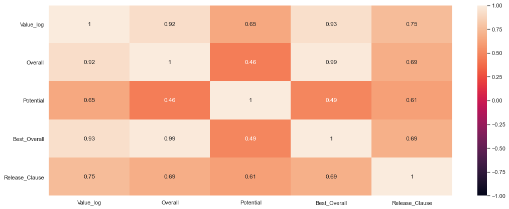

```python
#Heatmap of correlation values
plist_selected_features= plist[['Value_log','Overall','Potential','Best_Overall','Release_Clause']]
plt.figure(1, figsize=(18, 7))
sns.set(style="whitegrid")
sns.heatmap(plist_selected_features.corr(), annot=True, vmin=-1, vmax=1)
plt.yticks(rotation=0);
plt.show()
```

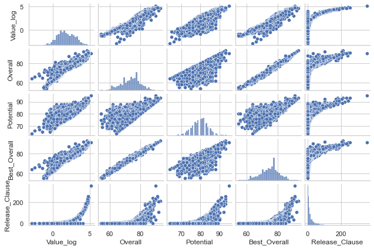

```python
#Pairplot of selected features
plt.figure(1, figsize=(18, 8))
sns.set(style="whitegrid")
g=sns.pairplot(plist_selected_features, height=1.2, aspect=1.5, palette="colorblind")
plt.yticks(rotation=90);
plt.show()
```

## Final Model

```python
Xs= plist.loc[:,['Overall','Potential','Best_Overall','Release_Clause']]
ys= plist.loc[:,"Value_log"]

pmodels = sm.OLS(ys, Xs, data=plist)

res_ss = pmodels.fit()

print(res_ss.summary());
```

```
                                 OLS Regression Results
=======================================================================================
Dep. Variable:              Value_log   R-squared (uncentered):                   0.920
Model:                            OLS   Adj. R-squared (uncentered):              0.920
Method:                 Least Squares   F-statistic:                              7265.
Date:                Sun, 16 May 2021   Prob (F-statistic):                        0.00
Time:                        16:51:46   Log-Likelihood:                         -2338.2
No. Observations:                2524   AIC:                                      4684.
Df Residuals:                    2520   BIC:                                      4708.
Df Model:                           4
Covariance Type:            nonrobust
==================================================================================
                     coef    std err          t      P>|t|      [0.025      0.975]
----------------------------------------------------------------------------------
Overall            0.0205      0.012      1.677      0.094      -0.003       0.045
Potential         -0.0622      0.002    -26.017      0.000      -0.067      -0.057
Best_Overall       0.0646      0.013      4.947      0.000       0.039       0.090
Release_Clause     0.0217      0.000     50.270      0.000       0.021       0.023
==============================================================================
Omnibus:                      624.573   Durbin-Watson:                   1.514
Prob(Omnibus):                  0.000   Jarque-Bera (JB):             2668.635
Skew:                          -1.137   Prob(JB):                         0.00
Kurtosis:                       7.495   Cond. No.                         197.
==============================================================================

Notes:
[1] R² is computed without centering (uncentered) since the model does not contain a constant.
[2] Standard Errors assume that the covariance matrix of the errors is correctly specified.
```

```python
#set up the 4 models:

X1= plist.loc[:,['Overall','Potential','Best_Overall','Release_Clause',]]
y1= plist.loc[:,"Value"]

yl = np.log1p(y1)

X_train, X_test, y_train, y_test = train_test_split(X1,yl,test_size=0.2, random_state=10)

X_train, X_val, y_train, y_val = train_test_split(X1,yl, test_size=.25, random_state=10)


lm = LinearRegression()

#Feature scaling for train, val, and test so that we can run our ridge model on each
scaler = StandardScaler()

X_train_scaled = scaler.fit_transform(X_train.values)
X_val_scaled = scaler.transform(X_val.values)
X_test_scaled = scaler.transform(X_test.values)

lm_reg = Ridge(alpha=0.05, normalize=True)

lm_lasso = Lasso(alpha=0.05, normalize=True)

#Feature transforms for train, val, and test so that we can run our poly model on each
poly = PolynomialFeatures(degree=2)

X1_poly = poly.fit_transform(X.values)
X_train_poly = poly.fit_transform(X_train.values)
X_val_poly = poly.transform(X_val.values)
X_test_poly = poly.transform(X_test.values)

lm_poly = LinearRegression()

lm.fit(X_train, y_train)
print("LINEAR REGRESSION FOR:")
print(f'All data R^2: {lm.score(X1, yl):.6f}')
print(f'Test data R^2: {lm.score(X_test, y_test):.6f}')
print(f'Validation data R^2: {lm.score(X_val, y_val):.6f}')
print("")

lm_reg.fit(X_train_scaled, y_train)
print("RIDGE REGRESSION FOR:")
print(f'Test data R^2: {lm_reg.score(X_test_scaled, y_test):.6f}')
print(f'Validation data R^2: {lm_reg.score(X_val_scaled, y_val):.6f}')
print("")


lm_lasso.fit(X_train,y_train)
print("LASSO REGRESSION FOR:")
print(f'Test data R^2: {lm_lasso.score(X_test, y_test):.6f}')
print(f'Validation data R^2: {lm_lasso.score(X_val, y_val):.6f}')
print("")

lm_poly.fit(X_train_poly, y_train)
print("SECOND DEGREE POLYNOMIAL REGRESSION FOR:")
print(f'Test data R^2: {lm_poly.score(X_test_poly, y_test):.6f}')
print(f'Validation data R^2: {lm_poly.score(X_val_poly, y_val):.6f}')
```

```
LINEAR REGRESSION FOR:
All data R^2: 0.928654
Test data R^2: 0.931279
Validation data R^2: 0.932199

RIDGE REGRESSION FOR:
Test data R^2: 0.930627
Validation data R^2: 0.931664

LASSO REGRESSION FOR:
Test data R^2: -0.002314
Validation data R^2: -0.002874

SECOND DEGREE POLYNOMIAL REGRESSION FOR:
Test data R^2: 0.961244
Validation data R^2: 0.962218
```

It turns out that the Polynomial regression produces the best results due to its r^2 value being the highest

```python
#Run Cross Validation

lm = LinearRegression()
kf = KFold(n_splits=10, shuffle=True, random_state = 10)
cross_val_score(lm, X1, yl, cv=kf, scoring='r2')

print(round(np.mean(cross_val_score(lm, X1, yl, cv=kf, scoring='r2')),5))
```

```
0.92802
```

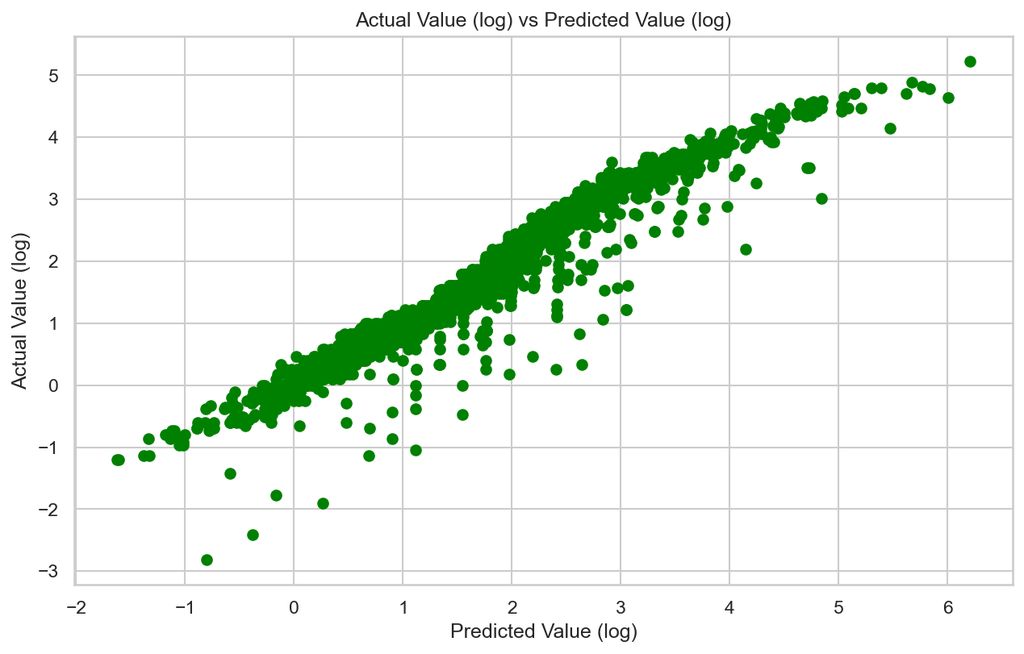

```python
# Regression Fit with Log
plt.figure(figsize=(10,6),dpi=150),
lr = LinearRegression()
fit = lr.fit(Xs,ys);
pred = lr.predict(Xs)
plt.scatter(pred,ys,color='green')
plt.title("Actual Value (log) vs Predicted Value (log)")
plt.xlabel("Predicted Value (log)")
plt.ylabel("Actual Value (log)")
```

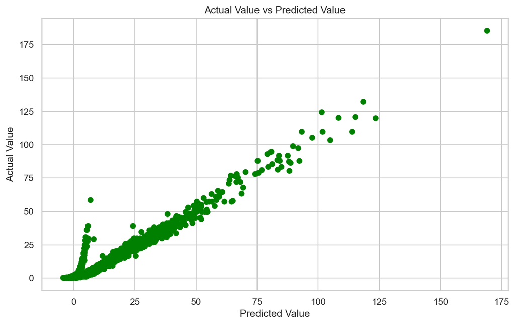

```python
# Regression Fit with Log
plt.figure(figsize=(10,6),dpi=150),
lr = LinearRegression()
fit = lr.fit(Xs,np.exp(ys));
pred = lr.predict(Xs)
plt.scatter(pred,np.exp(ys), color='green')
plt.title("Actual Value vs Predicted Value")
plt.xlabel("Predicted Value")
plt.ylabel("Actual Value")
```

## Results

Now it's time to find the most overrated and underrated players on the FIFA 2021 video game

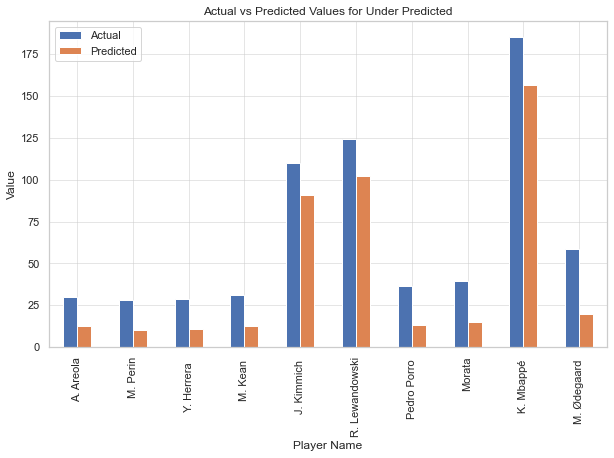

```python
#comparision of Actual and Predicted Values for Under Predicted plot
df_over[["Actual","Predicted"]].plot(kind='bar',figsize=(10,6))
plt.grid(linewidth='0.5')
plt.title("Actual vs Predicted Values for Under Predicted")
plt.xlabel("Player Name")
plt.ylabel('Value')
```

According to our results, the most overrated players in world soccer include the likes of Martin Ødegaard, Kylian Mbappé, and Joshua Kimmich. These players are some of world soccer's best but according to our model, the players are overvalued in today's market. This definitely comes as a surprise as these are very highly rated players already. However, player like Morata and Moise Kean are some players that you may expect to be on this list just based on general media perception

[figure not shown]

```python
#Plot the comparision of Actual and Predicted Values for Over Predicted
df_under[["Actual","Predicted"]].plot(kind='bar',figsize=(10,6))
plt.grid(linewidth='0.5')
plt.title("Actual vs Predicted Values for Over Predicted")
plt.xlabel("Player Name")
plt.ylabel('Value')
```

As for underrated players, some players appear here as well. The biggest one being Lionel Messi, arguably the greatest soccer player of all time, is considered underrated according to our model whicjh possible speaks to just how amazing of a player he is. His teammates, Coutinho and Dembélé also feature on the list. Maybe this means that Barcelona, the club they play for needs to hike up their asking price for these players.

## Conclusion

I was able to use prediction models to determine which statistics are important in determining if a soccer player is overvalued and undervalued. The regression model looked good and it gave us some good variables to consider for estimating a player's worth in today's market.

The model worked well and looks like it could be a good predictor of a player's value. Though not perfect, a model that predicts with 100% accuracy using analytics alone is basically impossible, as there are many more factors outside the world of analytics that need to be considered. As of now there is no concrete, objective criteria given clubs to determine a players value, but perhaps the statistics the model marked above could help clubs dictate what would be a good price for a play to go for.